# Copepod Starvation Project Summary

Matthew Sasaki

2022-08-02

## Data Summary

```r
knitr::opts_chunk$set(
  echo = T,
  fig.align = "center",
  fig.path = "../output/figures/markdown/",
  message = FALSE,
  warning = FALSE,
  collapse = T,
  dev = c("png", "pdf")
)

library(tidyverse)
library(dabestr)
library(ggbeeswarm)
library(RColorBrewer)
library(knitr)
library(DT)
library(plotly)
library(MuMIn)
library(kableExtra)
library(ggpubr)

theme_matt = function(base_size){
  ggpubr::theme_pubr(base_family="sans") %+replace%
    theme(
      panel.background  = element_blank(),
      plot.background = element_rect(fill="transparent", colour=NA),
      legend.background = element_rect(fill="transparent", colour=NA),
      legend.key = element_rect(fill="transparent", colour=NA),
      legend.text = element_text(size=base_size * 0.8),
      legend.title = element_text(size = base_size * 0.8,
                                  face = "bold"),
      axis.text = element_text(size = base_size),
      axis.title = element_text(size = base_size * 1.4),
      title = element_text(size = base_size * 1.55)
    )
}

diet_cols = c("tet" = "darkolivegreen3",
              "rhod" = "#BE4C2F",
              "control" = "slategray2",
              "oxy" = "rosybrown2")
```

## Motivation

Copepods are some of the most abundant animals on the planet. They are globally distributed, and play key ecological roles in aquatic habitats. However, despite their ubiquity and ecological importance, there is only limited data available on their thermal limits. This impedes our ability to predict how copepods may be affected by increasing temperatures, both over short (e.g. - seasonal changes or heatwaves) and long timescales (e.g. - climate change). Further, the available data is strongly skewed both in terms of phylogenetic coverage (focusing on the orders Calanoida and Harpacticoida) and habitats (focusing marine and intertidal copepods), which is compounded by the fact that there is a strong correlation between order and habitat in the collected data (marine calanoids, freshwater cyclopoids, and intertidal harpacticoids). This project aims to collect thermal limit data for a diverse range of copepods from both marine and freshwater habitats. By collecting all three orders from both habitats, I will break the order-habitat correlation that characterizes existing data. By collecting copepods throughout the year from both habitats, this project will also examine how vulnerable copepods are during different seasons to acute warming events like heat waves.

## Measuring Thermal Limits

### HOTbox (“Heating Over Time” box)

We used a custom set-up to measure copepod thermal tolerance, designed to prioritize portability and affordability. The apparatus has three components: a reservoir, a water bath, and a temperature sensor. We used a 5 gallon bucket covered with a neoprene sleeve as our reservoir. The reservoir was filled with ~20 L of water, which is slowly warmed using a 300 watt aquarium water heater. The reservoir also contains two aquarium pumps, one of which circulates water within the reservoir while the other pumps water from the reservoir into the water bath, which sits atop the reservoir. In this arrangement, the temperature ramping rate is determined by the interaction between the power output of the aquarium heater and the volume of water in the reservoir.

The water bath is a transparent plexiglass box that fits over the opening of the reservoir. Water is pumped up from the reservoir at a rapid rate, flooding the water bath. A recession cut into one of the edges of the box allows water to spill back into the reservoir. The water bath contains several test-tube holders that are used to secure the experimental vessels (50 mL flat-bottom glass vials) during the CTmax trials. Because the box is transparent, individuals are easily monitored through the side of the water bath throughout the trial, eliminating the necessity to remove experimental vessels from the water bath, potentially inducing temperature fluctuations.

The final component of this apparatus is a small Arduino computer system that logs temperature with three independent sensors at 5 second intervals. These sensors are small enough to be placed inside the same experimental vessels used during the CTmax trials, providing a continuous record of the temperatures within the vessels. Data is written to a microUSB card for easy access. No horizontal gradients in temperature were detected within the water bath, and temperatures are averaged across the three sensors.

The set-up described above can increase water temperatures in the experimental vessels at steady rates between 0.1 - 0.3 degrees C per minute, which have previously been used to measure CTmax for copepods. It is also highly portable - most of the components fit within the empty five gallon bucket, allowing for easy transport or shipping. The cost of the unit is also relatively low compared to the other devices commonly used to measure CTmax, which generally cost upwards of $1000.

### CTmax Trials

Individual copepod critical thermal maxima (CTmax) were measured using the device described above. CTmax is generally defined as the temperature at which the individual ceases to respond to gentle physical stimulus (further described below), indicating the onset of “ecological death” (the inability to escape lethal temperatures, predators, etc.). This is measured by exposing copepods to slowly increasing temperatures and monitoring individual behavior. The reservoir is filled with 20 L of water and adjusted to match the temperature copepods were collected at by either adding ice (to cool) or using the heater (to warm). After the reservoir reaches the proper temperature, experimental vessels containing 10 mL of the appropriate medium are placed in the water bath, which is then flooded with water, bringing the experimental vessels to the correct temperature as well. Individual copepods are then placed into the vials, and let acclimate for 30 minutes at constant temperature. All copepods are checked during and after this time period to ensure they are exhibiting normal behaviors before temperatures begin to increase.

After this resting phase, the water heater is turned on, initiating the temperature ramp. Simultaneously, the temperature logger begins to record temperature and a stop watch begins recording the time passed. Individuals are then continuously monitored as water temperature increases. Copepods not actively moving are checked by either 1) slowly rotating the glass vial, causing slight water movement; or 2) using a plastic transfer pipette to gently flush the contents of the vial. The time at which an individual stops responding to these stimuli is recorded (in minutes and seconds). Other indications that an individual has reached their CTmax are i) a sustained position on the floor of the vessel, ii) antennules that have curved inwards or are held at abnormal angles, and iii) a backwards arching of the urosome above the prosome. After the individual reaches its CTmax, the experimental vessel is removed from the water bath. As is expected for CTmax measurements, most individuals recover after being removed from the thermal stress conditions and resume normal swimming behaviors. After the trial is completed, all individuals are photographed using a camera attached to an inverted scope (or the equivalent), and body size estimated using a scale micrometer and ImageJ. Individuals are then preserved in 95% ethanol for later genetic identification and analysis.

The times recorded during the trials are then converted to the CTmax values in degrees C, using the continuous temperature record logged by the Arduino system. There is an “uncertainty window” for each measurement, however, that also has to be accounted for - as there are between 1-10 vials being monitored at any point in the trial, the time at which an individual was recorded as having stopped responding to stimulus corresponds with the latest time (and therefore highest temperature) it could have reached its CTmax at. The period of time during which an individual could have reached its CTmax extends from this definite end point to the last time the individual was checked. As it generally takes around 5 seconds to check whether an individual has stopped responding, the duration of this uncertainty window was estimated for each individual as the number of vials remaining in the water bath multiplied by 5 seconds. As such, the uncertainty window decreased in length as the trial went on, until, for the final individual, the window includes just the amount of time it took to check whether the individual had stopped responding. CTmax is estimated as the average temperatures recorded by all three temperature sensors throughout the uncertainty window.

We used this time-based method instead of directly monitoring the temperature for two reasons: 1) it was faster to record the time an individual stopped responding than to check the temperature readings from the three sensors, increasing the resolution of our measurements (since temperature increased continuously rather than in a step-wise manner); and 2) it reduces any sub-conscious bias stemming from past knowledge or expectations about copepod thermal limits.

## Results

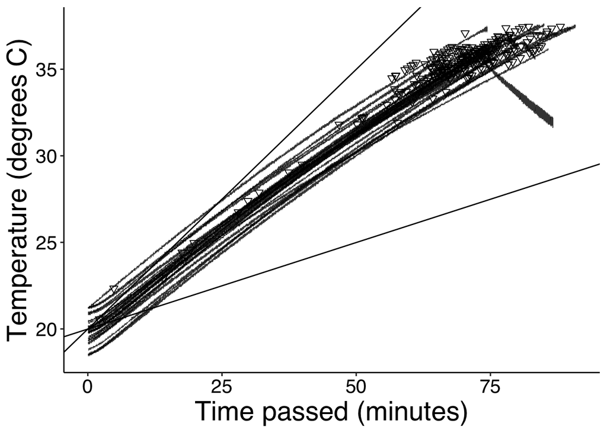

```r
ggplot(temp_record, aes(x = minute_passed, y = temp_C, group = factor(run))) +
  geom_abline(slope = 0.3, intercept = mean(temp_record[temp_record$minute_interval == 0, 8])) +
  geom_abline(slope = 0.1, intercept = mean(temp_record[temp_record$minute_interval == 0, 8])) +
  geom_line(size = 0.2, alpha = 0.8) +
  geom_point(data = full_data,
             aes(x = time, y = ct_max + 0.4),
             size = 2,
             shape = 25) +
  labs(x = "Time passed (minutes)",
       y = "Temperature (degrees C)",
       fill = "Trial Number") +
  guides(colour = "none") +
  theme_matt(base_size = 16) +
  theme(legend.position = "right")
```

Ramping rates during these trials (the increase in temperature per minute) decrease over time due to the imperfect insulation of the bucket reservoir. Ramping rates are almost always between the target ramping rates of 0.3 and 0.1 degrees C per minute. The plot below is a hexagonal heatmap of ramping rate throughout the CTmax trials. The plane is divided into regular hexagons, which are shaded according the frequency of the encompassed ramping rates.

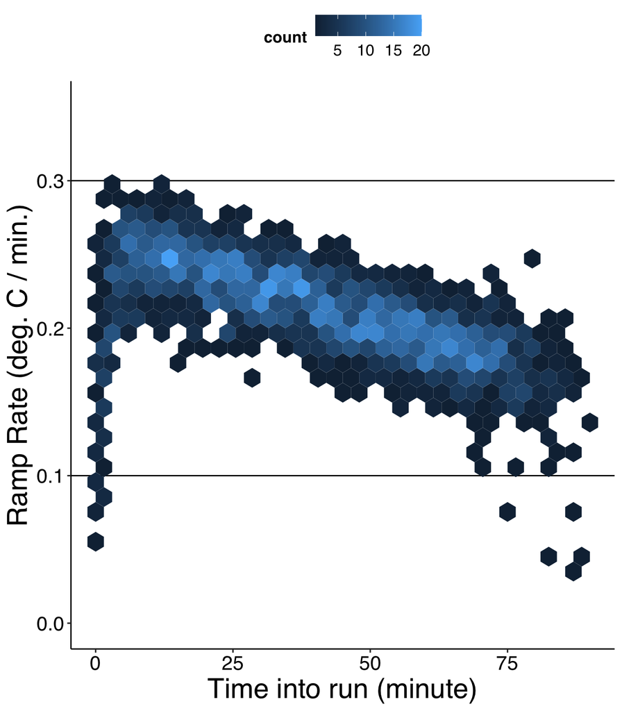

```r
ramp_record2 = ramp_record %>%
  group_by(run, minute_interval) %>%
  summarise(mean_ramp = mean(ramp_per_minute))

ggplot(ramp_record2, aes(x = minute_interval, y = mean_ramp)) +
  geom_hline(yintercept = 0.3) +
  geom_hline(yintercept = 0.1) +
  #geom_point() +
  geom_hex(bins = 30) +
  ylim(0, 0.35) +
  labs(y = "Ramp Rate (deg. C / min.)",
       x = "Time into run (minute)") +
  theme_matt(base_size = 16)
```

### Experiment 1 - Diet composition

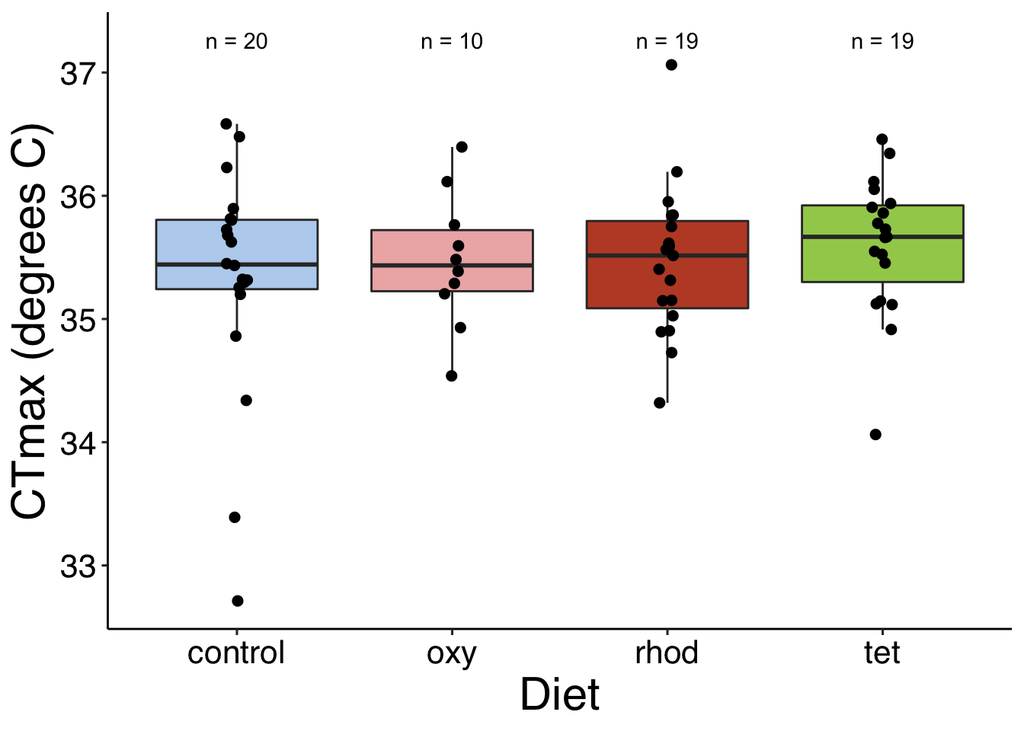

```r
exp1_data = full_data %>%
  filter(experiment == "one")

exp1_n = exp1_data %>%
  group_by(diet) %>%
  count() %>%
  mutate(n = paste("n =", n, sep = " "))

ggplot(exp1_data, aes(x = diet, y = ct_max, fill = diet)) +
  geom_boxplot(outlier.colour = NA) +
  geom_jitter(width = 0.05, height = 0, size = 2) +
  annotate(geom = "text", x = exp1_n$diet, y = max(exp1_data$ct_max) + 0.2, label = exp1_n$n) +
  labs(x = "Diet",
       y = "CTmax (degrees C)") +
  scale_fill_manual(values= diet_cols) +
  #scale_fill_viridis(discrete = T) +
  theme_matt(base_size = 16) +
  theme(legend.position = "none")
```

```r
exp1_lin.model = lm(data = exp1_data,
                    ct_max ~ diet)

# exp1_lin.model_result = car::Anova(exp1_lin.model)
#
# kable(exp1_lin.model_result,
#       format = "html",
#       digits = 2,
#       align = "c")

exp1_lme.model = lme4::lmer(data = exp1_data,
                            ct_max ~ diet + (1|run))

exp1_lme.model_result = car::Anova(exp1_lme.model)

kable(exp1_lme.model_result,
      format = "html",
      digits = 2,
      align = "c")
```

|  | Chisq | Df | Pr(>Chisq) |
| --- | --- | --- | --- |
| diet | 1.29 | 3 | 0.73 |

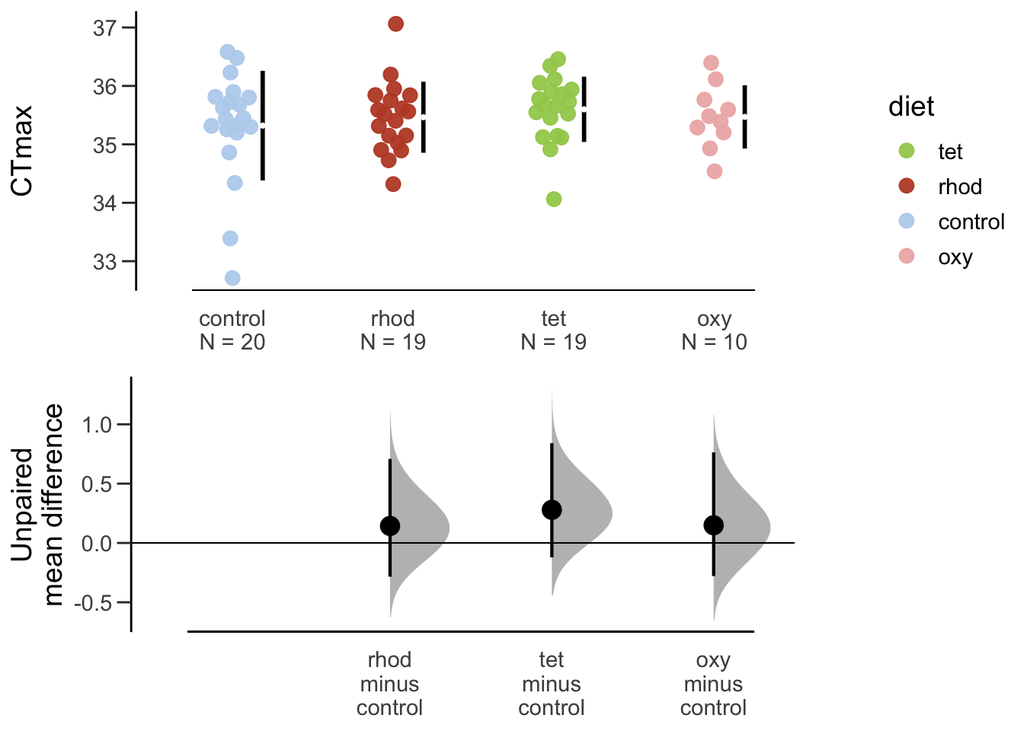

```r
exp1_est = exp1_data %>%
  dabest(x = diet, y = ct_max,
         idx = c("control", "rhod", "tet", "oxy")) %>%
  mean_diff()

plot(exp1_est,
     rawplot.markersize = 3,
     color.column = diet,
     palette = diet_cols,
     rawplot.groupwidth = 0.15,
     rawplot.ylabel = "CTmax")
```

### Experiment 2 - Temporal patterns

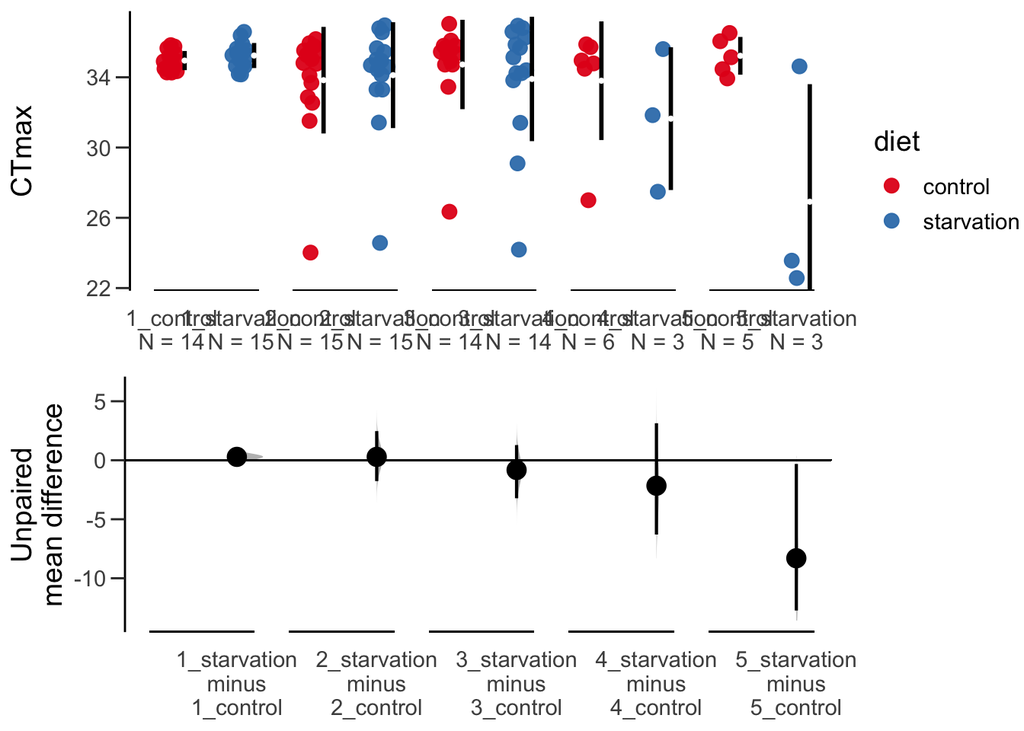

```r
exp2_data = full_data %>%
  filter(experiment == "two" & ct_max > 22) %>%
  mutate("cumul_day" = as.numeric(as.Date(run_date) - first(as.Date(run_date))),
         "rep" = case_when(
           cumul_day < 6 ~ 1,
           cumul_day > 19 ~ 3,
           cumul_day > 6 ~ 2)) %>%
  group_by(rep) %>%
  mutate("rep_day" = cumul_day - first(cumul_day))

exp2_pairs_eff = exp2_data %>%
  mutate(eff_id = paste(rep_day, diet, sep = "_")) %>%
  filter(rep_day != 0) %>%
  dabest(x = eff_id, y = ct_max,
         idx = list(c("1_control", "1_starvation"),
                    c("2_control","2_starvation"),
                    c("3_control","3_starvation"),
                    c("4_control","4_starvation"),
                    c("5_control","5_starvation"))) %>%
  mean_diff()

plot(exp2_pairs_eff,
     rawplot.markersize = 3,
     color.column = diet,
     rawplot.groupwidth = 0.15,
     rawplot.ylabel = "CTmax")
```

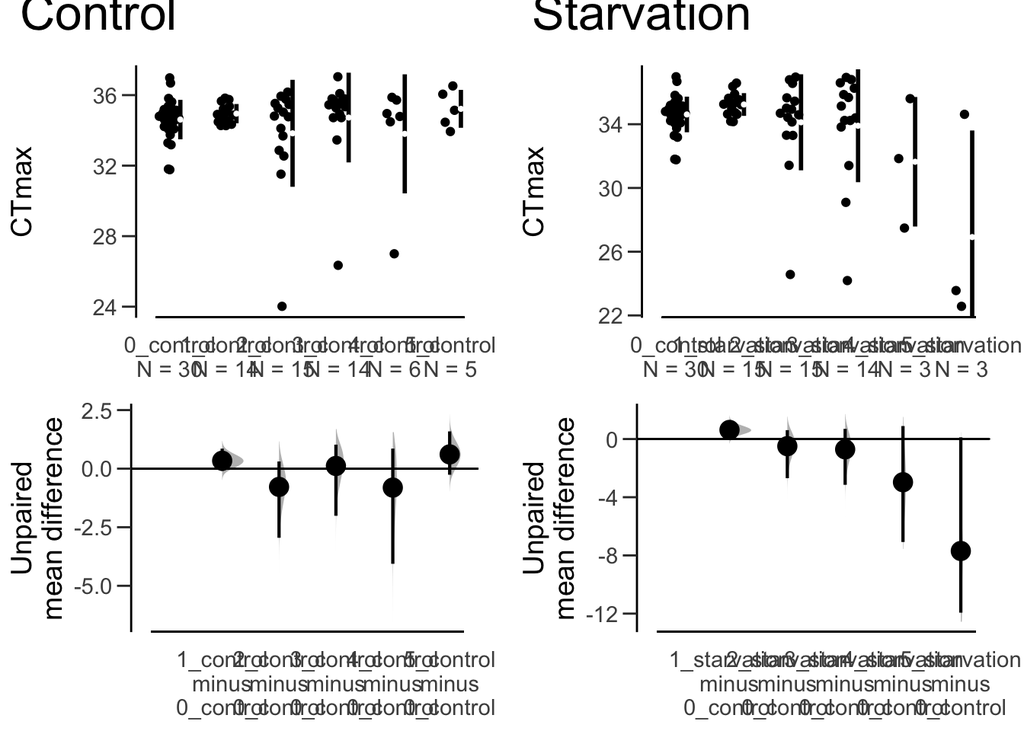

```r
exp2_control_eff = exp2_data %>%
  mutate(eff_id = paste(rep_day, diet, sep = "_")) %>%
  mutate(rep_day = as.numeric(rep_day)) %>%
  dabest(eff_id, ct_max,
         idx = c("0_control", "1_control", "2_control", "3_control", "4_control", "5_control"),
         paired = FALSE) %>%
  mean_diff()

param_list = list()
param_list[["colour"]] = "black"
param_list[["width"]] = 0.2

a = plot(exp2_control_eff,
         rawplot.markersize = 3,
         rawplot.groupwidth = 0.15,
         rawplot.ylabel = "CTmax",
         swarmplot.params = param_list)


exp2_starv_eff = exp2_data %>%
  mutate(eff_id = paste(rep_day, diet, sep = "_")) %>%
  mutate(rep_day = as.numeric(rep_day)) %>%
  dabest(eff_id, ct_max,
         idx = c("0_control", "1_starvation", "2_starvation", "3_starvation", "4_starvation", "5_starvation"),
         paired = FALSE) %>%
  mean_diff()

b = plot(exp2_starv_eff,
         rawplot.markersize = 3,
         rawplot.groupwidth = 0.15,
         rawplot.ylabel = "CTmax",
         swarmplot.params = param_list)

a_title = ggplot() +
  ggtitle("Control") +
  theme_minimal(base_size = 20)

b_title = ggplot() +
  ggtitle("Starvation") +
  theme_minimal(base_size = 20)

ggarrange(a_title, b_title, a, b, common.legend = T, nrow = 2, ncol = 2, heights = c(0.08,1))
```

```r
rep_list = unique(exp2_data$rep)

exp2_effects = data.frame()
for(i in 1:length(rep_list)){

  rep_data = exp2_data %>%
    filter(rep == i) %>%
    mutate(eff_id = paste(rep_day, diet, sep = "_")) %>%
    mutate(rep_day = as.numeric(rep_day)) %>%
    select(diet, tube, ct_max, rep, rep_day, eff_id)

  control_eff = rep_data %>%
    dabest(eff_id, ct_max,
           idx = unique(c("0_control", rep_data$eff_id[str_detect(rep_data$eff_id, pattern = "control")])),
           paired = FALSE) %>%
    mean_diff()

  starv_eff = rep_data %>%
    mutate(eff_id = paste(rep_day, diet, sep = "_")) %>%
    mutate(rep_day = as.numeric(rep_day)) %>%
    dabest(eff_id, ct_max,
           idx = unique(c("0_control", rep_data$eff_id[str_detect(rep_data$eff_id, pattern = "starvation")])),
           paired = FALSE) %>%
    mean_diff()

  control_data = data.frame(
    "rep" = i,
    "diet" = "control",
    "effect" = control_eff$result$difference,
    "ci_low" = control_eff$result$bca_ci_low,
    "ci_high" = control_eff$result$bca_ci_high)%>%
    mutate("day" = row_number())

  starve_data = data.frame(
    "rep" = i,
    "diet" = "starvation",
    "effect" = starv_eff$result$difference,
    "ci_low" = starv_eff$result$bca_ci_low,
    "ci_high" = starv_eff$result$bca_ci_high) %>%
    mutate("day" = row_number())

  exp2_effects = bind_rows(exp2_effects, control_data, starve_data)
}
```

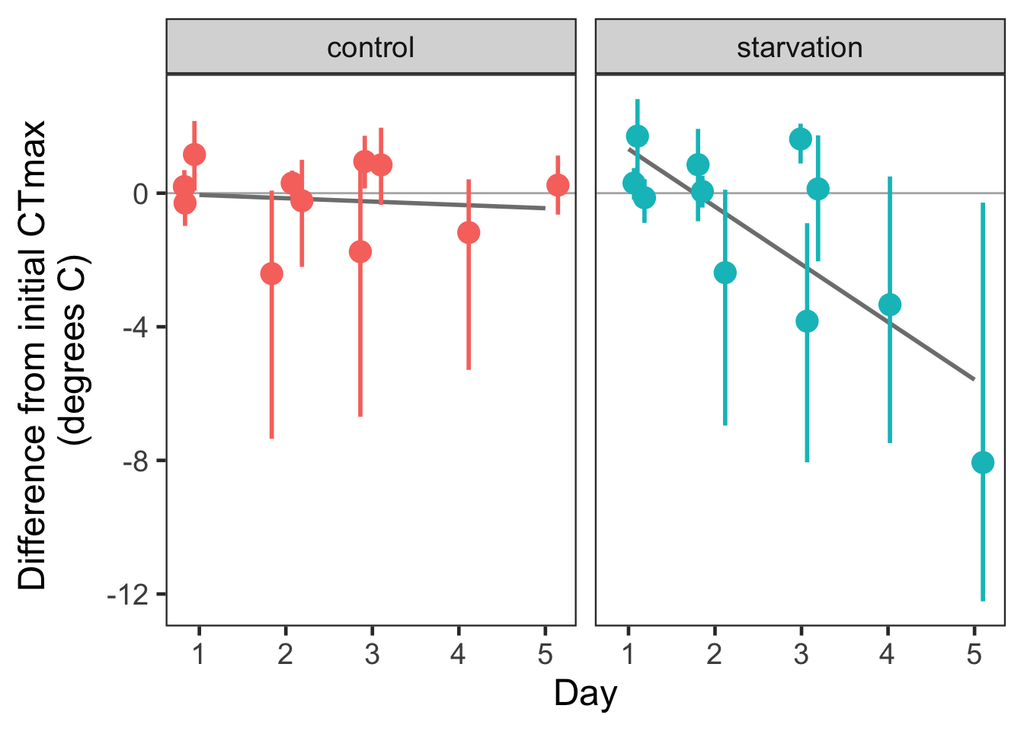

```r
ggplot(exp2_effects, aes(x = day, y = effect, colour = diet, group = diet)) +
  facet_wrap(.~diet) +
  geom_hline(yintercept = 0, colour = "grey70") +
  geom_smooth(method = "lm", se = F, colour = "grey50") +
  geom_pointrange(aes(ymin = ci_low, ymax = ci_high),
                  position=position_jitter(width = 0.2),
                  size = 1) +
  # geom_errorbar(aes(ymin = ci_low, ymax = ci_high),
  #               position = position_dodge(),
  #               width = 0.1, size = 1) +
  # geom_point(position = position_dodge(width = 0.1),
  #            size = 3) +
  labs(x = "Day",
       y = "Difference from initial CTmax \n(degrees C)") +
  theme_bw(base_size = 18) +
  theme(legend.position = "none",
        panel.grid = element_blank())
```

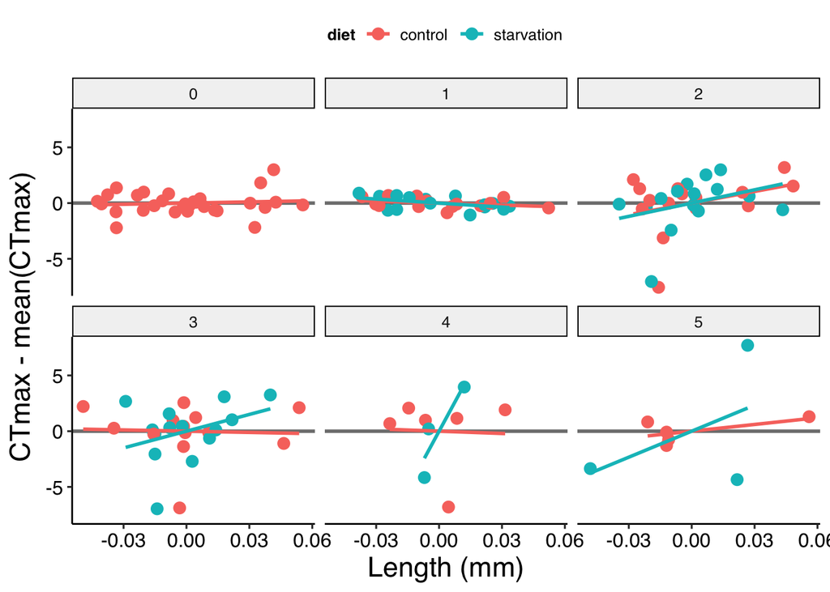

```r
mean_diff = exp2_data %>%
  group_by(rep, rep_day, diet) %>%
  mutate("mean_diff" = ct_max - mean(ct_max),
         "mean_diff_length" = length - mean(length))

ggplot(mean_diff, aes(x = mean_diff_length, y = mean_diff, colour = diet)) +
  facet_wrap(.~rep_day) +
  geom_hline(yintercept = 0, size = 1, colour = "grey50") +
  geom_point(size = 3) +
  geom_smooth(method = "lm", se = F, size = 1) +
  labs(x = "Length (mm)",
       y = "CTmax - mean(CTmax)") +
  theme_matt(base_size = 12)
```